# Introduction to Statistics in R

Solutions

# Overview

The goal of this workshop is to introduce core statistical concepts using **simple base R syntax** and a real clinical dataset from the **OncoDataSets** package.

Topics covered:

- Data exploration and visualization
- Descriptive statistics
- Hypothesis testing (t-test, chi-square)
- Linear regression (OLS)
- Kaplan–Meier survival analysis
- Log-rank test

# Step 0: Install and Load Required Packages

```r
#install.packages("OncoDataSets")
#install.packages("survival")

library(OncoDataSets)
library(survival)
```

# Exercise 1: Load and Explore the Breast Cancer Dataset

We will use the `BreastCancer_df` dataset, which contains demographic, tumour, and survival information for patients with breast cancer. Paste these commands into your script to rename the dataset and generate an (artificial) tumor size variable, which would not otherwise be present in the dataset.

```r
data("WBreastCancer_tbl_df")
BreastCancer_df <- WBreastCancer_tbl_df

BreastCancer_df$tumour_size <- abs(round(15 + rnorm(length(BreastCancer_df$age),25,10)
                               - 0.25*BreastCancer_df$age + BreastCancer_df$histgrad
                               *-(rgamma(length(BreastCancer_df$histgrad),3)),0))
```

## Tasks

1. View the first few rows of the dataset
2. Examine the structure of the dataset
3. Obtain summary statistics

```r
head(BreastCancer_df)
```

```
##   id      time status er age histgrad ln_yesno pathsd pr tumour_size
## 1  1  9.466667      0  0  60        3        0     NA  0          13
## 2  2  8.600000      0 NA  79       NA        0     NA NA          NA
## 3  3 19.333333      0 NA  82        2        0     NA NA          19
## 4  4 16.333333      0  1  66        2        0     NA  1          28
## 5  5  8.500000      0 NA  52        3        0     NA NA          11
## 6  6  9.400000      0 NA  58       NA        0     NA NA          NA
```

```r
str(BreastCancer_df)
```

```
## Classes 'tbl_df', 'tbl' and 'data.frame':    1207 obs. of  10 variables:
##  $ id         : num  1 2 3 4 5 6 7 8 9 10 ...
##   ..- attr(*, "format.spss")= chr "F8.0"
##   ..- attr(*, "display_width")= int 4
##  $ time       : num  9.47 8.6 19.33 16.33 8.5 ...
##   ..- attr(*, "format.spss")= chr "F8.2"
##  $ status     : num  0 0 0 0 0 0 0 0 0 0 ...
##   ..- attr(*, "format.spss")= chr "F8.0"
##  $ er         : num  0 NA NA 1 NA NA 1 0 NA 1 ...
##   ..- attr(*, "format.spss")= chr "F6.0"
##  $ age        : num  60 79 82 66 52 58 50 83 46 54 ...
##   ..- attr(*, "format.spss")= chr "F8.0"
##  $ histgrad   : num  3 NA 2 2 3 NA 2 3 NA 2 ...
##   ..- attr(*, "format.spss")= chr "F8.0"
##  $ ln_yesno   : num  0 0 0 0 0 0 0 0 1 1 ...
##   ..- attr(*, "format.spss")= chr "F8.0"
##  $ pathsd     : num  NA NA NA NA NA NA NA NA NA NA ...
##   ..- attr(*, "format.spss")= chr "F8.0"
##  $ pr         : num  0 NA NA 1 NA NA 0 0 NA 1 ...
##   ..- attr(*, "format.spss")= chr "F6.0"
##  $ tumour_size: num  13 NA 19 28 11 NA 0 3 NA 12 ...
##   ..- attr(*, "format.spss")= chr "F8.0"
```

```r
summary(BreastCancer_df)
```

```
##        id              time             status              er
##  Min.   :   1.0   Min.   :  2.633   Min.   :0.00000   Min.   :0.000
##  1st Qu.: 310.5   1st Qu.: 22.550   1st Qu.:0.00000   1st Qu.:0.000
##  Median : 619.0   Median : 42.967   Median :0.00000   Median :1.000
##  Mean   : 621.1   Mean   : 46.956   Mean   :0.05965   Mean   :0.611
##  3rd Qu.: 931.5   3rd Qu.: 65.583   3rd Qu.:0.00000   3rd Qu.:1.000
##  Max.   :1266.0   Max.   :133.800   Max.   :1.00000   Max.   :1.000
##                                                       NA's   :338
##       age           histgrad       ln_yesno          pathsd
##  Min.   :22.00   Min.   :1.00   Min.   :0.0000   Min.   :0.0000
##  1st Qu.:46.00   1st Qu.:2.00   1st Qu.:0.0000   1st Qu.:0.0000
##  Median :56.00   Median :2.00   Median :0.0000   Median :0.0000
##  Mean   :56.39   Mean   :2.27   Mean   :0.2303   Mean   :0.2632
##  3rd Qu.:66.50   3rd Qu.:3.00   3rd Qu.:0.0000   3rd Qu.:1.0000
##  Max.   :88.00   Max.   :3.00   Max.   :1.0000   Max.   :1.0000
##                  NA's   :287                     NA's   :86
##        pr          tumour_size
##  Min.   :0.0000   Min.   : 0.00
##  1st Qu.:0.0000   1st Qu.:10.00
##  Median :1.0000   Median :18.00
##  Mean   :0.5429   Mean   :18.76
##  3rd Qu.:1.0000   3rd Qu.:26.00
##  Max.   :1.0000   Max.   :51.00
##  NA's   :356      NA's   :287
```

# Exercise 2: Descriptive Statistics and Visualization

## Tasks

1. Generate an appropriate graph (either histogram or bar chart) for Age, Hormone Receptor Status, and Tumour Size.
2. Comment on the distribution of numerical variables.

## Histogram of Age

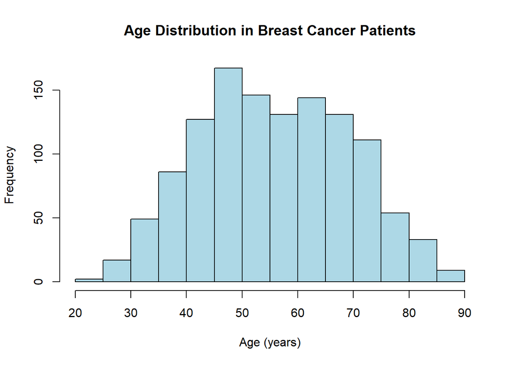

```r
hist(BreastCancer_df$age,
main = "Age Distribution in Breast Cancer Patients",
xlab = "Age (years)",
col = "lightblue")
```

## Bar Chart of Hormone Receptor Status

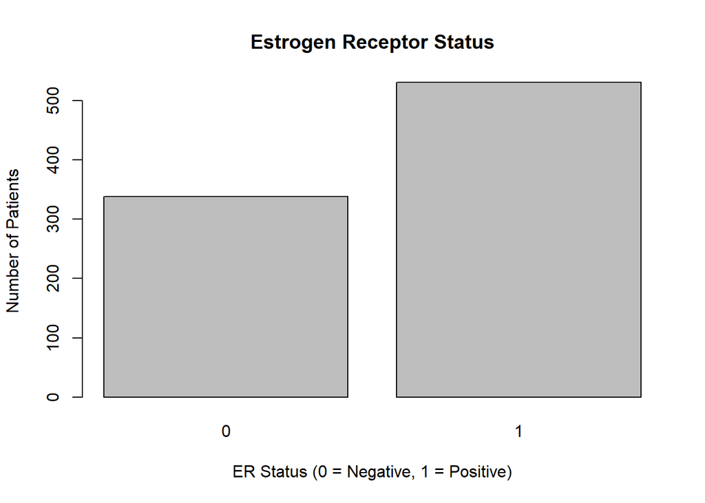

```r
barplot(table(BreastCancer_df$er),
main = "Estrogen Receptor Status",
xlab = "ER Status (0 = Negative, 1 = Positive)",
ylab = "Number of Patients")
```

## Histogram of Tumour Size

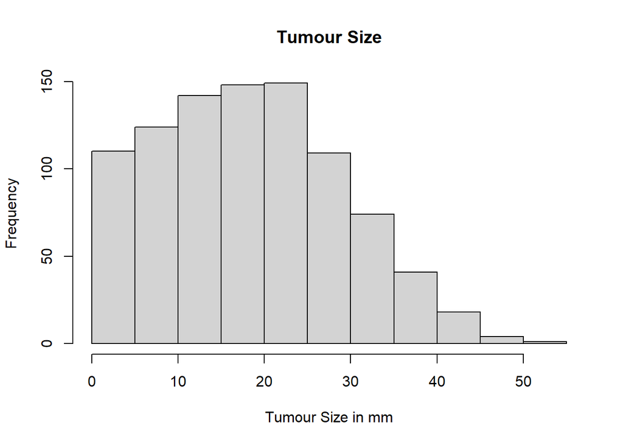

```r
hist(BreastCancer_df$tumour_size,
main = "Tumour Size",
xlab = "Tumour Size in mm")
```

# Exercise 3: Two-Sample t-Test

Is age different between ER-positive and ER-negative patients?

## Tasks

1. Obtain counts for ER status
2. Test if ER status is associated with a difference in the average age at diagnosis.

```r
table(BreastCancer_df$er)
```

```
##
##   0   1
## 338 531
```

```r
t.test(age ~ er, data = BreastCancer_df)
```

```
##
##  Welch Two Sample t-test
##
## data:  age by er
## t = -7.5115, df = 685.01, p-value = 1.83e-13
## alternative hypothesis: true difference in means between group 0 and group 1 is not equal to 0
## 95 percent confidence interval:
##  -8.605477 -5.038948
## sample estimates:
## mean in group 0 mean in group 1
##        52.16272        58.98493
```

# Exercise 4: Chi-Square Test

Is ER status associated with nodal involvement?

## Tasks

1. Obtain counts for ER status and Nodal status
2. Test if there is an association between ER status and Nodal status

```r
contingency <- table(BreastCancer_df$er, BreastCancer_df$ln_yesno)
contingency
```

```
##
##       0   1
##   0 255  83
##   1 394 137
```

```r
chisq.test(contingency)
```

```
##
##  Pearson's Chi-squared test with Yates' continuity correction
##
## data:  contingency
## X-squared = 0.10969, df = 1, p-value = 0.7405
```

# Exercise 5: Linear Regression (OLS)

Does age predict tumour size?

## Tasks

1. Using OLS, check if age can predict tumour size
2. Plot the relationship

```r
model <- lm(tumour_size ~ age, data = BreastCancer_df)
summary(model)
```

```
##
## Call:
## lm(formula = tumour_size ~ age, data = BreastCancer_df)
##
## Residuals:
##     Min      1Q  Median      3Q     Max
## -24.341  -7.879  -0.337   6.914  32.021
##
## Coefficients:
##             Estimate Std. Error t value Pr(>|t|)
## (Intercept) 31.25664    1.46887  21.279   <2e-16 ***
## age         -0.22310    0.02551  -8.747   <2e-16 ***
## ---
## Signif. codes:  0 '***' 0.001 '**' 0.01 '*' 0.05 '.' 0.1 ' ' 1
##
## Residual standard error: 10.33 on 918 degrees of freedom
##   (287 observations deleted due to missingness)
## Multiple R-squared:  0.07693,    Adjusted R-squared:  0.07592
## F-statistic: 76.51 on 1 and 918 DF,  p-value: < 2.2e-16
```

## Plot the Relationship

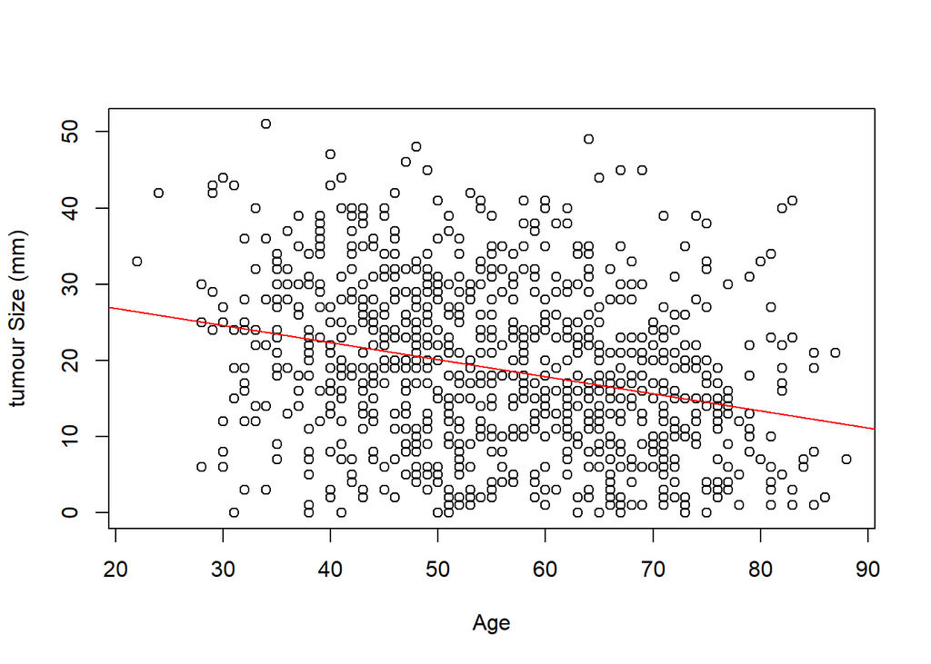

```r
plot(BreastCancer_df$age, BreastCancer_df$tumour_size,
xlab = "Age",
ylab = "tumour Size (mm)")
abline(model, col = "red")
```

# Exercise 6: Kaplan–Meier Survival Analysis

## Tasks

1. Create a survival table
2. Fit a KM curve to the survival table
3. Plot the KM curves

Assume `status == 1` indicates death and `0` indicates censoring.

```r
surv_obj <- Surv(BreastCancer_df$time, BreastCancer_df$status)
```

## Fit Kaplan–Meier Curves by ER Status

```r
km_fit <- survfit(surv_obj ~ er, data = BreastCancer_df)
```

## Plot Survival Curves

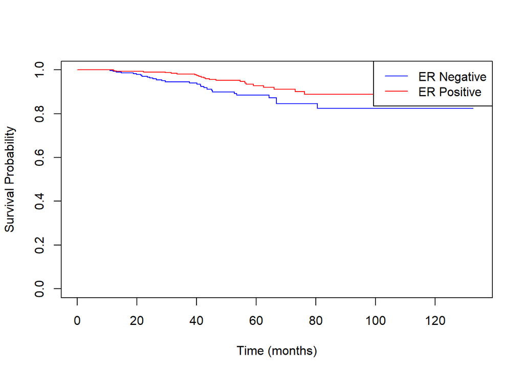

```r
plot(km_fit,
col = c("blue", "red"),
xlab = "Time (months)",
ylab = "Survival Probability")
legend("topright",
legend = c("ER Negative", "ER Positive"),
col = c("blue", "red"),
lty = 1)
```

# Exercise 7: Log-Rank Test

## Tasks

1. Compare Survival by ER Status
2. Comment on the prognostic value of ER status

```r
survdiff(surv_obj ~ er, data = BreastCancer_df)
```

```
## Call:
## survdiff(formula = surv_obj ~ er, data = BreastCancer_df)
##
## n=869, 338 observations deleted due to missingness.
##
##        N Observed Expected (O-E)^2/E (O-E)^2/V
## er=0 338       28     19.8      3.39      5.54
## er=1 531       23     31.2      2.15      5.54
##
##  Chisq= 5.5  on 1 degrees of freedom, p= 0.02
```